# Saqrlab Reference — TNA simulation

## `simulate_htna()`

Simulate a transition matrix with multiple node *types* for hierarchical (HTNA), multilevel (MLNA), or multi-type (MTNA) analysis. Returns `list(matrix, node_types, type_names, n_nodes_per_type)`. `simulate_mlna()` and `simulate_mtna()` are aliases that produce identical output — choose the name matching your analysis context.

**Signature**

```r
args(simulate_htna)
```

```
#> function (n_nodes = 5, n_types = 5, type_names = c("Metacognitive",
#>     "Cognitive", "Behavioral", "Social", "Motivational"), within_prob = 0.4,
#>     between_prob = 0.15, weight_range = c(0, 1), allow_self_loops = FALSE,
#>     categories = c("metacognitive", "cognitive", "behavioral",
#>         "social", "motivational"), seed = NULL)
#> NULL
```

**Example**

```r
htna <- simulate_htna(n_nodes = 2, n_types = 2, seed = 1)
names(htna)
```

```
#> [1] "matrix"           "node_types"       "type_names"       "n_nodes_per_type"
```

```r
htna$type_names
```

```
#> [1] "Metacognitive" "Cognitive"
```

```r
dim(htna$matrix)
```

```
#> [1] 4 4
```

```r
round(htna$matrix, 3)
```

```
#>         Reflect Adapt Read Study
#> Reflect       0     0    0     0
#> Adapt         0     0    1     0
#> Read          0     0    0     0
#> Study         0     0    0     0
```

```r
round(rowSums(htna$matrix), 3)
```

```
#> Reflect   Adapt    Read   Study
#>       0       1       0       0
```

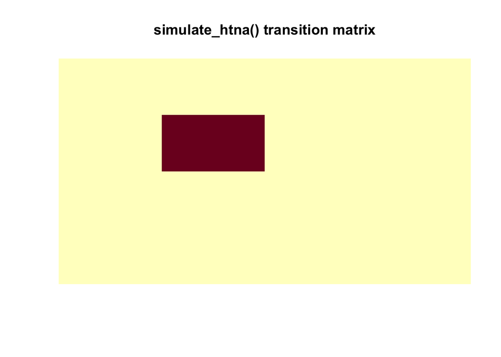

```r
# a quick heatmap of the transition structure
image(htna$matrix, axes = FALSE, main = "simulate_htna() transition matrix")
```

## `simulate_mlna()`

Multilevel-network alias of `simulate_htna()` — identical behaviour and return value; the name simply documents intent in multilevel (MLNA) workflows.

**Signature**

```r
args(simulate_mlna)
```

```
#> function (n_nodes = 5, n_types = 5, type_names = c("Metacognitive",
#>     "Cognitive", "Behavioral", "Social", "Motivational"), within_prob = 0.4,
#>     between_prob = 0.15, weight_range = c(0, 1), allow_self_loops = FALSE,
#>     categories = c("metacognitive", "cognitive", "behavioral",
#>         "social", "motivational"), seed = NULL)
#> NULL
```

**Example**

```r
mlna <- simulate_mlna(
  n_nodes = 2,
  type_names = c("Macro", "Meso", "Micro"),
  seed = 1
)
mlna$type_names
```

```
#> [1] "Macro" "Meso"  "Micro"
```

```r
dim(mlna$matrix)
```

```
#> [1] 6 6
```

```r
round(rowSums(mlna$matrix), 3)
```

```
#>  Reflect    Adapt     Read    Study Organize Exercise
#>        1        1        1        1        1        0
```

## `simulate_mtna()`

Multi-type-network alias of `simulate_htna()` — identical behaviour and return value, named for multi-type (MTNA) workflows.

**Signature**

```r
args(simulate_mtna)
```

```
#> function (n_nodes = 5, n_types = 5, type_names = c("Metacognitive",
#>     "Cognitive", "Behavioral", "Social", "Motivational"), within_prob = 0.4,
#>     between_prob = 0.15, weight_range = c(0, 1), allow_self_loops = FALSE,
#>     categories = c("metacognitive", "cognitive", "behavioral",
#>         "social", "motivational"), seed = NULL)
#> NULL
```

**Example**

```r
mtna <- simulate_mtna(n_nodes = 2, n_types = 3, seed = 1)
mtna$type_names
```

```
#> [1] "Metacognitive" "Cognitive"     "Behavioral"
```

```r
dim(mtna$matrix)
```

```
#> [1] 6 6
```

```r
round(rowSums(mtna$matrix), 3)
```

```
#>  Reflect    Adapt     Read    Study Organize Exercise
#>        1        1        1        1        1        0
```

## `simulate_matrix()`

Generate a single simple network matrix (transition, frequency, co-occurrence, or adjacency) with learning-state node names. A transition matrix is row-normalised (rows sum to 1).

**Signature**

```r
args(simulate_matrix)
```

```
#> function (n_nodes = 9, matrix_type = c("transition", "frequency",
#>     "co-occurrence", "adjacency"), edge_prob = 0.3, weighted = TRUE,
#>     weight_range = c(0, 1), directed = TRUE, allow_self_loops = FALSE,
#>     names = NULL, seed = NULL)
#> NULL
```

**Example**

```r
mat <- simulate_matrix(n_nodes = 4, matrix_type = "transition", seed = 1)
dim(mat)
```

```
#> [1] 4 4
```

```r
round(mat, 3)
```

```
#>         Reflect Adapt  Plan Monitor
#> Reflect    0.00     0 0.000   0.000
#> Adapt      0.00     0 0.231   0.769
#> Plan       0.00     1 0.000   0.000
#> Monitor    0.63     0 0.370   0.000
```

```r
round(rowSums(mat), 3)                  # rows sum to 1 (empty rows -> 0)
```

```
#> Reflect   Adapt    Plan Monitor
#>       0       1       1       1
```

```r
# co-occurrence is symmetric
co <- simulate_matrix(n_nodes = 4, matrix_type = "co-occurrence", seed = 1)
isSymmetric(co)
```

```
#> [1] TRUE
```

## `generate_tna_matrix()`

Backward-compatibility alias of `simulate_tna_matrix()` — see that section for full documentation. It forwards all arguments unchanged.

**Signature**

```r
args(generate_tna_matrix)
```

```
#> function (...)
#> NULL
```

**Example**

```r
net <- generate_tna_matrix(nodes_per_group = 2, n_groups = 2, seed = 1, verbose = FALSE)
identical(names(net), c("matrix", "node_types"))
```

```
#> [1] TRUE
```

```r
dim(net$matrix)
```

```
#> [1] 4 4
```

## `generate_tna_networks()`

Backward-compatibility alias of `simulate_tna_networks()` — see that section for full documentation. It forwards all arguments unchanged.

**Signature**

```r
args(generate_tna_networks)
```

```
#> function (...)
#> NULL
```

**Example**

```r
nets <- generate_tna_networks(
  n_networks = 2, n_states = 4, n_sequences = 30, seq_length = 10,
  seed = 1, verbose = FALSE
)
length(nets)
```

```
#> [1] 2
```

```r
class(nets[[1]])
```

```
#> [1] "tna"
```

## `generate_tna_datasets()`

Backward-compatibility alias of `simulate_tna_datasets()` — see that section for full documentation. It forwards all arguments unchanged.

**Signature**

```r
args(generate_tna_datasets)
```

```
#> function (...)
#> NULL
```

**Example**

```r
data <- generate_tna_datasets(
  n_datasets = 2, n_states = 4, n_sequences = 30, seq_length = 10,
  seed = 1, verbose = FALSE
)
length(data)
```

```
#> [1] 2
```

```r
names(data[[1]])
```

```
#> [1] "model"            "params"           "transition_probs" "initial_probs"
#> [5] "sequences"
```

## `generate_group_tna_networks()`

Backward-compatibility alias of `simulate_group_tna_networks()` — see that section for full documentation. It forwards all arguments unchanged.

**Signature**

```r
args(generate_group_tna_networks)
```

```
#> function (...)
#> NULL
```

**Example**

```r
g <- generate_group_tna_networks(
  n_groups = 2, n_actors = 5, n_states = 3, seq_length_range = c(5, 8),
  seed = 1, verbose = FALSE
)
class(g)
```

```
#> [1] "group_tna"
```

```r
length(g)
```

```
#> [1] 2
```

## `generate_probabilities()`

Generate random transition probabilities and initial-state probabilities for a Markov chain (via `seqHMM`). Returns `list(initial_probs, transition_probs, state_names)`; transition-matrix rows sum to 1.

**Signature**

```r
args(generate_probabilities)
```

```
#> function (n_states = 8, states = NULL, alpha = 1, diag_c = 0,
#>     seed = NULL, possible_state_names = NULL)
#> NULL
```

**Example**

```r
probs <- generate_probabilities(n_states = 4, seed = 1)
names(probs)
```

```
#> [1] "initial_probs"    "transition_probs" "state_names"
```

```r
probs$state_names
```

```
#> [1] "A" "B" "C" "D"
```

```r
round(probs$initial_probs, 3)
```

```
#>     A     B     C     D
#> 0.033 0.402 0.386 0.179
```

```r
sum(probs$initial_probs)                # initial probs sum to 1
```

```
#> [1] 1
```

```r
round(probs$transition_probs, 3)
```

```
#>       A     B     C     D
#> A 0.332 0.315 0.269 0.084
#> B 0.092 0.152 0.301 0.454
#> C 0.018 0.339 0.273 0.369
#> D 0.266 0.122 0.266 0.345
```

```r
round(rowSums(probs$transition_probs), 3)
```

```
#> A B C D
#> 1 1 1 1
```

## `generate_sequence_data()`

Backward-compatibility alias of `simulate_tna_datasets()` — see that section for full documentation. It forwards all arguments unchanged, returning the full datasets bundle (model + probabilities + sequences).

**Signature**

```r
args(generate_sequence_data)
```

```
#> function (...)
#> NULL
```

**Example**

```r
seqs <- generate_sequence_data(
  n_datasets = 1, n_states = 4, n_sequences = 30, seq_length = 10,
  seed = 1, verbose = FALSE
)
length(seqs)
```

```
#> [1] 1
```

```r
names(seqs[[1]])
```

```
#> [1] "model"            "params"           "transition_probs" "initial_probs"
#> [5] "sequences"
```

```r
head(seqs[[1]]$sequences, 3)
```

|  | V1 | V2 | V3 | V4 | V5 | V6 | V7 | V8 | V9 | V10 |
| --- | --- | --- | --- | --- | --- | --- | --- | --- | --- | --- |
| 1 | Plan | Monitor | Adapt | Monitor | Adapt | Adapt | Monitor | Adapt | Adapt | Monitor |
| 2 | Adapt | Monitor | Reflect | Reflect | Reflect | Reflect | Monitor | Reflect | Reflect | Adapt |
| 3 | Adapt | Monitor | Reflect | Reflect | Reflect | Adapt | Monitor | Reflect | Reflect | Reflect |

## `sample_tna()`

Take a fitted `tna` model (or a sequence `data.frame`), randomly sample a proportion of its rows, and re-estimate a new `tna` model with the same parameters. `sampling_percent` must be in `(0, 1]`. Useful for sampling-stability and bootstrap-style studies.

**Signature**

```r
args(sample_tna)
```

```
#> function (model, sampling_percent = 0.3, model_type = NULL, scaling = NULL)
#> NULL
```

**Example**

```r
model   <- simulate_tna_network(n_states = 4, seed = 1)
sampled <- sample_tna(model, sampling_percent = 0.5)
class(sampled)
```

```
#> [1] "tna"
```

```r
nrow(model$data)                        # rows in the original model
```

```
#> [1] 728
```

```r
nrow(sampled$data)                      # ~50% of the rows, re-estimated
```

```
#> [1] 364
```

```r
head(round(sampled$weights, 3))
```

```
#>               Analyze Differentiate Elaborate Track
#> Analyze         0.350         0.259     0.023 0.369
#> Differentiate   0.130         0.278     0.249 0.343
#> Elaborate       0.167         0.305     0.096 0.432
#> Track           0.199         0.297     0.118 0.386
```